# ML Project-wk-4

Phillip

9/3/2020

## Executive Summary:

In this project, we will use data from accelerometers on the belt, forearm, arm, and dumbell of 6 participants. Accelerometers have been widely accepted as useful and practical sensors for wearable devices to measure and assess physical activity. We will observe some of these wearable accelerometry-based motion detectors in action. Using devices such as Jawbone Up, Nike FuelBand, and Fitbit it is now possible to collect a large amount of data about personal activity relatively inexpensively. These type of devices are part of the quantified self movement to improve the individual’s health.

## We are loading the necessary libraries:

##library(dplyr) ##library(ggplot2) ##library(tidyverse) ##library(lubridate)

## We are loading and preprocessing the data.

```r
P_Train <- read.csv("pmi-training.csv", header = TRUE, na.strings = "NA")
P_Test <- read.csv("pmi-testing.csv", header = TRUE, na.strings = "NA")
```

## we are working with the analysis of the selected variables: Use data from accelerometers on the belt, forearm, arm, and dumbell of 6 participants. We will observe the results from their performance of lifting the barbell lifts correctly and incorrectly in 5 different ways.

## We are displaying a summary of the data:

```r
My_Ex <-  P_Train %>% select(accel_belt_y, accel_dumbbell_x)


summary(My_Ex)
```

```
##   accel_belt_y    accel_dumbbell_x
##  Min.   :-69.00   Min.   :-419.00
##  1st Qu.:  3.00   1st Qu.: -50.00
##  Median : 35.00   Median :  -8.00
##  Mean   : 30.15   Mean   : -28.62
##  3rd Qu.: 61.00   3rd Qu.:  11.00
##  Max.   :164.00   Max.   : 235.00
```

```r
My_Ex1 <-  P_Train %>% select(accel_arm_x, accel_arm_z)

summary(My_Ex1)
```

```
##   accel_arm_x       accel_arm_z
##  Min.   :-404.00   Min.   :-636.00
##  1st Qu.:-242.00   1st Qu.:-143.00
##  Median : -44.00   Median : -47.00
##  Mean   : -60.24   Mean   : -71.25
##  3rd Qu.:  84.00   3rd Qu.:  23.00
##  Max.   : 437.00   Max.   : 292.00
```

```r
My_Ex2  <-  P_Train %>% select(accel_belt_z, accel_dumbbell_y)

summary(My_Ex2)
```

```
##   accel_belt_z     accel_dumbbell_y
##  Min.   :-275.00   Min.   :-189.00
##  1st Qu.:-162.00   1st Qu.:  -8.00
##  Median :-152.00   Median :  41.50
##  Mean   : -72.59   Mean   :  52.63
##  3rd Qu.:  27.00   3rd Qu.: 111.00
##  Max.   : 105.00   Max.   : 315.00
```

```r
My_model <- lm(My_Ex)

My_model
```

```
##
## Call:
## lm(formula = My_Ex)
##
## Coefficients:
##      (Intercept)  accel_dumbbell_x
##          33.5166            0.1175
```

```r
My_model1 <- lm(My_Ex1)


My_model1
```

```
##
## Call:
## lm(formula = My_Ex1)
##
## Coefficients:
## (Intercept)  accel_arm_z
##    -74.2712      -0.1969
```

```r
My_model2 <- lm(My_Ex2)

My_model2
```

```
##
## Call:
## lm(formula = My_Ex2)
##
## Coefficients:
##      (Intercept)  accel_dumbbell_y
##         -93.7081            0.4012
```

## We are using the t.test to analyze the statistical results.

```r
My_TT <- t.test(My_Ex, data = P_Train)

My_TT
```

```
##
##  One Sample t-test
##
## data:  My_Ex
## t = 2.5633, df = 39243, p-value = 0.01037
## alternative hypothesis: true mean is not equal to 0
## 95 percent confidence interval:
##  0.1811214 1.3580693
## sample estimates:
## mean of x
## 0.7695954
```

```r
## One Sample t-test
```

## BoxPlot 1

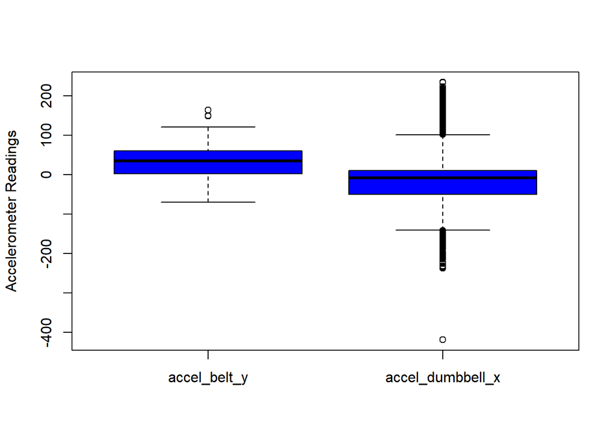

```r
My_TT <- t.test(My_Ex, data = P_Train)


boxplot(My_Ex, data = P_Train, col = "blue", ylab = "Accelerometer Readings")
```

```r
My_TT1 <- t.test(My_Ex1, data = P_Train)

My_TT1
```

```
##
##  One Sample t-test
##
## data:  My_Ex1
## t = -81.294, df = 39243, p-value < 2.2e-16
## alternative hypothesis: true mean is not equal to 0
## 95 percent confidence interval:
##  -67.32771 -64.15756
## sample estimates:
## mean of x
## -65.74264
```

```r
## One Sample t-test
```

## Boxplot 2

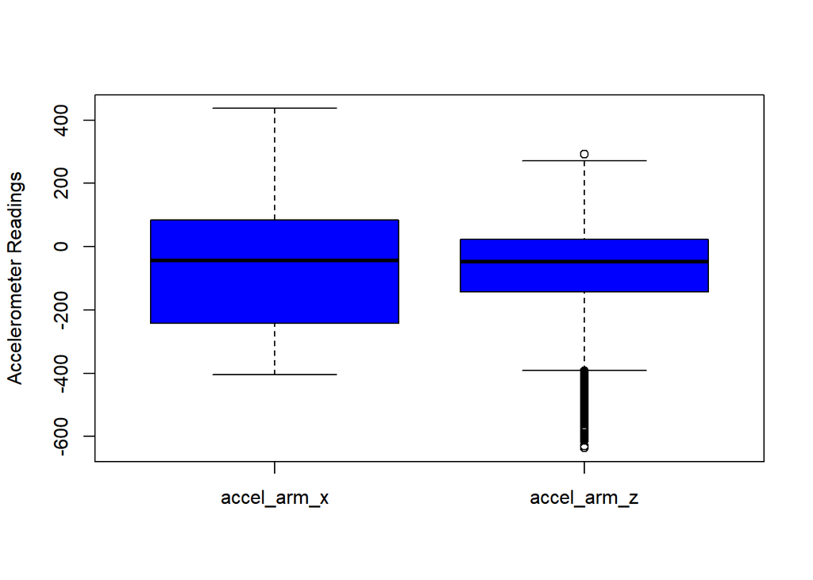

```r
My_TT1 <- t.test(My_Ex1, data = P_Train)

boxplot(My_Ex1, data = P_Train, col = "blue", ylab = "Accelerometer Readings")
```

```r
My_TT2 <- t.test(My_Ex2, data = P_Train)

My_TT2
```

```
##
##  One Sample t-test
##
## data:  My_Ex2
## t = -17.881, df = 39243, p-value < 2.2e-16
## alternative hypothesis: true mean is not equal to 0
## 95 percent confidence interval:
##  -11.074175  -8.886227
## sample estimates:
## mean of x
## -9.980201
```

```r
## One Sample t-test
```

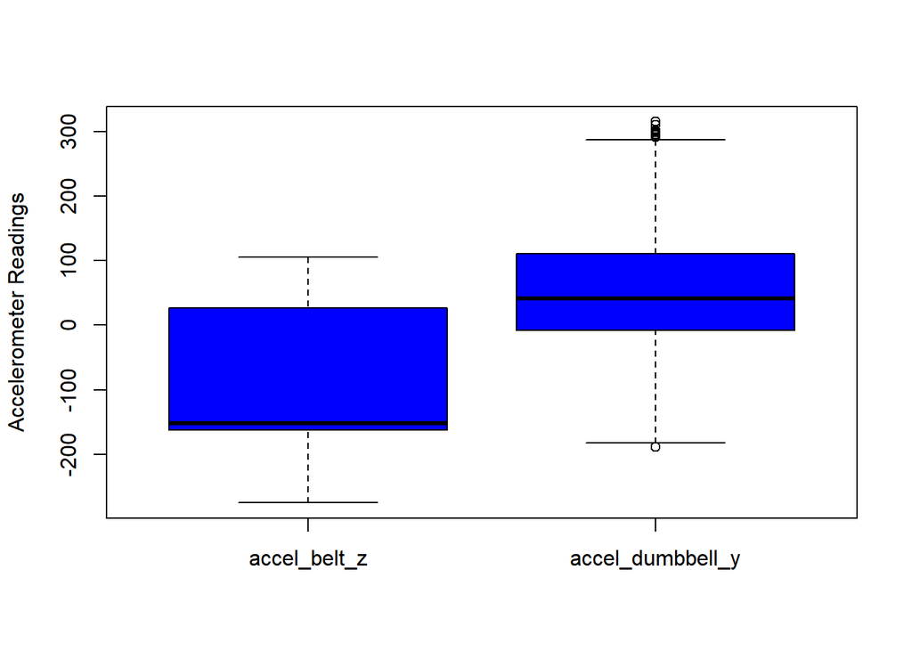

```r
My_TT2 <- t.test(My_Ex2, data = P_Train)


boxplot(My_Ex2, data = P_Train, col = "blue", ylab = "Accelerometer Readings")
```

conclusion:

In this project, we showed the data from accelerometers on the belt, forearm, arm, and dumbell of participants. Accelerometers have shown to focus individuals attention increase movement toward a healter lifestyle.